# Context-dependent activity of enhancer-blocking insulators in plants

## Insulators or silencers?

To test if the insulator fragments act as insulators or silencers, we cloned them between the 35S enhancer and the 35S minimal promoter or upstream of both elements. This gave rise to the **i/sLib** library which showed high replicate correlations.

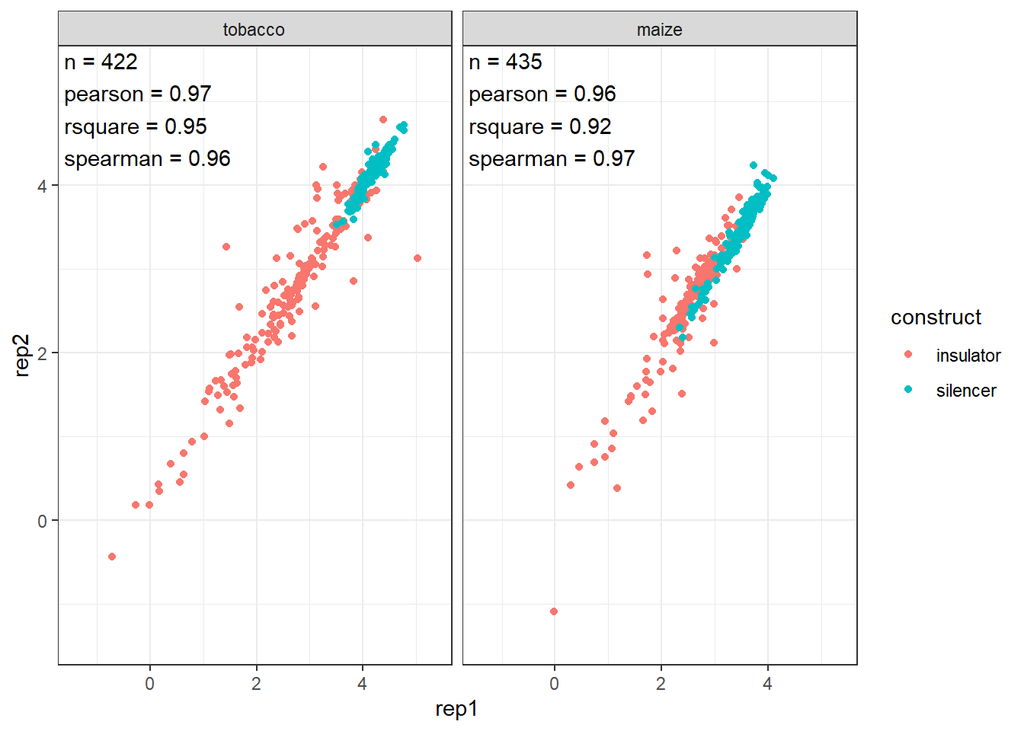

```r
data_isLib_norm |>
  select(rep, sys, construct, insulator, start, stop, orientation, enrichment) |>
  filter(construct != 'control') |>
  pivot_wider(
    names_from = rep,
    names_prefix = 'rep',
    values_from = enrichment
  ) |>
  drop_na(starts_with('rep')) |>
  pggfplot(
    filename = 'isLib_cor_rep',
    x = rep1,
    y = rep2,
    facet_col = sys,
    scales = 'square'
  ) |>
  pggf_scatter(color = construct) |>
  pggf_stats(!! pggf_stat_fns$correlation)
```

Insulator fragments reduce the enrichment of the reporter construct when the 35S enhancer is cloned upstream of them. When the insulator fragments reside upstream of the 35S enhancer, they are largely inactive.

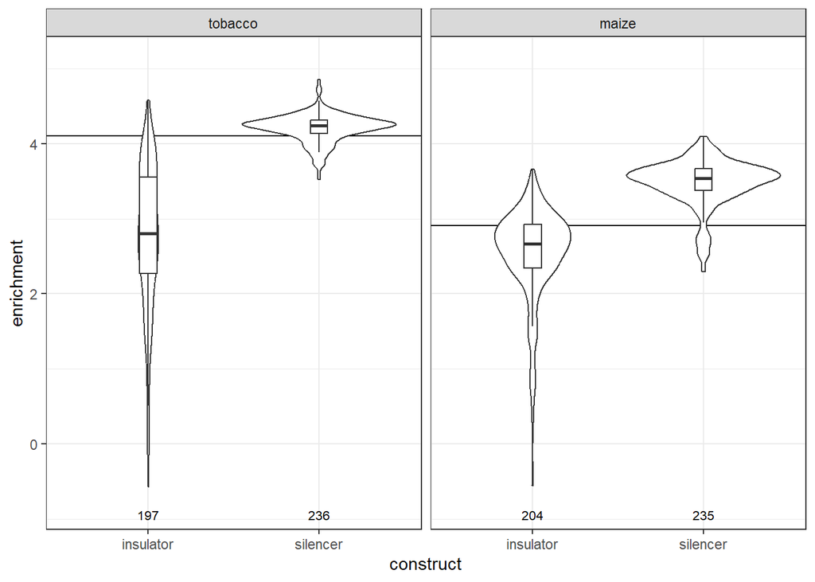

```r
data_isLib_mean |>
  group_by(sys) |>
  mutate(
    noIns = enrichment[insulator == 'noIns']
  ) |>
  ungroup() |>
  filter(type != 'control') |>
  mutate(
    construct = ordered(construct, levels = c('insulator', 'silencer'))
  ) |>
  pggfplot(
    filename = 'isLib_enrichment',
    x = construct,
    y = enrichment,
    facet_col = sys
  ) |>
  pggf_hline(unique(noIns)) |>
  pggf_violin()
```

We can plot the enrichment of the silencer constructs against the enrichment of the insulator constructs to see if the tested fragments behave more like insulators or silencers.

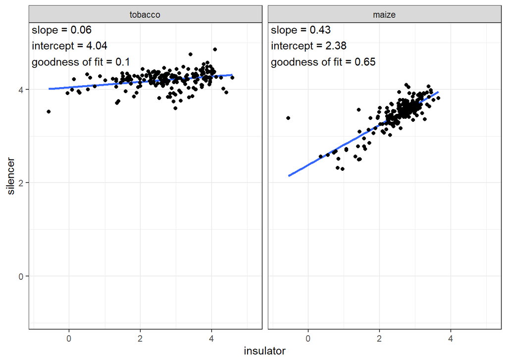

```r
data_isLib_mean |>
  select(sys, construct, insulator, start, stop, orientation, enrichment) |>
  unite(
    'id',
    insulator,
    start,
    stop,
    orientation,
    na.rm = TRUE
  ) |>
  filter(construct != 'control') |>
  pivot_wider(
    names_from = construct,
    values_from = enrichment
  ) |>
  drop_na(insulator, silencer) |>
  pggfplot(
    filename = 'isLib_IvS',
    x = insulator,
    y = silencer,
    facet_col = sys,
    scales = 'square'
  ) |>
  pggf_trendline() |>
  pggf_stats(!! pggf_stat_fns$trendline) |>
  pggf_scatter()
```

Export data to a Supplementary Data file:

```r
DS_id <- 4

data_isLib_export <- data_isLib_mean |>
  select(sys, construct, insulator, start, stop, orientation, enrichment) |>
  pivot_wider(
    names_from = sys,
    values_from = enrichment
  ) |>
  arrange(construct, insulator, orientation, start, stop) |>
  mutate(
    sequence = str_sub(FLins_seqs[as.character(insulator)], start, stop),
    sequence = if_else(
      orientation == 'rev',
      as.character(Biostrings::reverseComplement(Biostrings::DNAStringSet(replace_na(sequence, 'A')))),
      sequence
    ),
    sequence = replace_na(sequence, ''),
    insulator = str_replace(insulator, 'beta', 'β'),
    insulator = str_replace(insulator, 'lambda', 'λ')
  )

wb <- createWorkbook()

modifyBaseFont(wb, fontSize = 10, fontName = 'Arial')

addWorksheet(wb, sheetName = 'insulator v silencer constructs')

writeData(
  wb,
  sheet = 1,
  paste0('Supplementary Dataset S', DS_id,'. Enrichment of insulator fragments in insulator and silencer constructs.'),
  startCol = 1,
  startRow = 1
)

makeNameBold(wb, DS_id)
mergeCells(wb, sheet = 1, rows = 1, cols = seq_len(ncol(data_isLib_export)))

writeData(
  wb,
  sheet = 1,
  paste(
    "Insulator fragments were cloned in between (insulator construct) or upstream of (silencer construct) a 35S enhancer and a 35S minimal",
    "promoter driving the expression of a barcoded GFP reporter gene. All constructs were pooled and subjected to Plant STARR-seq in",
    "N. benthamiana leaves (tobacco) or maize protoplasts (maize). Reporter mRNA enrichment was normalized to a control construct without an",
    "enhancer or insulator (noEnh; log2 set to 0)."
  ),
  startCol = 1,
  startRow = 2
)

addStyle(wb, sheet = 1, style = xlsx_wrap, rows = 2, cols = 1)
mergeCells(wb, sheet = 1, rows = 2, cols = seq_len(ncol(data_isLib_export)))
setRowHeights(wb, sheet = 1, rows = 2, heights = 12.75 * 5)

xlsx_header <- names(data_isLib_export)
enrichment_ids <- which(xlsx_header %in% c('tobacco', 'maize'))
xlsx_header[enrichment_ids] <- 'log2(enrichment)'

writeData(
  wb,
  sheet = 1,
  matrix(xlsx_header, nrow = 1),
  startCol = 1,
  startRow = 4,
  colNames = FALSE
)

addStyle(wb, sheet = 1, style = xlsx_boldwrap, cols = seq_along(xlsx_header), rows = 4)

writeData(
  wb,
  sheet = 1,
  data_isLib_export,
  startCol = 1,
  startRow = 5,
  headerStyle = xlsx_bold,
  keepNA = TRUE
)

mergeCells(wb, sheet = 1, rows = 4, cols = enrichment_ids)
addStyle(wb, sheet = 1, style = xlsx_center, rows = 4, cols = enrichment_ids, stack = TRUE)

for (i in seq_along(xlsx_header)[-enrichment_ids]) {
  mergeCells(wb, sheet = 1, rows = 4:5, cols = i)
}

addStyle(wb, sheet = 1, style = xlsx_2digit, cols = enrichment_ids, rows = 6:(nrow(data_isLib_export) + 6), gridExpand = TRUE)
addStyle(wb, sheet = 1, style = xlsx_seq_font, cols = which(xlsx_header == 'sequence'), rows = 6:(nrow(data_isLib_export) + 6))

freezePane(wb, sheet = 1, firstActiveRow = 6)

saveWorkbook(wb, paste0(supp_data_dir, 'SupplementaryDataset', DS_id, '.xlsx'), overwrite = TRUE)
```

## Enhancer-insulator combinations

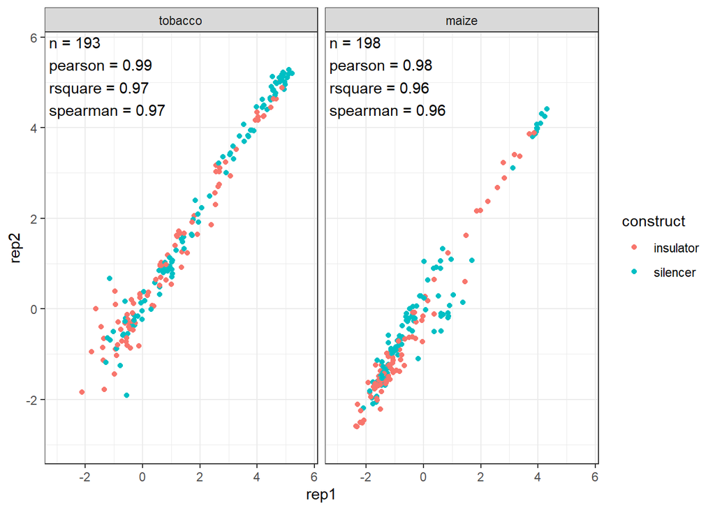

```r
data_ExI_norm |>
  filter(construct != 'noEnh') |>
  select(rep, sys, construct, enhancer, insulator, start, stop, enrichment) |>
  pivot_wider(
    names_from = rep,
    names_prefix = 'rep',
    values_from = enrichment
  ) |>
  drop_na(starts_with('rep')) |>
  pggfplot(
    filename = 'ExI_cor_rep',
    x = rep1,
    y = rep2,
    facet_col = sys,
    scales = 'square'
  ) |>
  pggf_scatter(color = construct) |>
  pggf_stats(!! pggf_stat_fns$correlation)
```

First, let’s see how strong the different enhancers are.

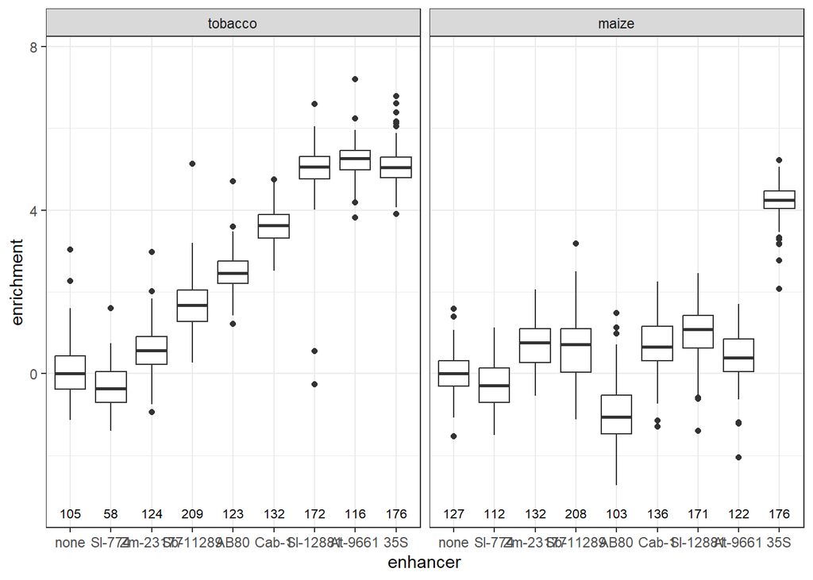

```r
data_ExI_enhancers |>
  group_by(enhancer) |>
  mutate(
    rank = unique(rank[sys == 'tobacco'])
  ) |>
  ungroup() |>
  mutate(
    enhancer = ordered(enhancer, levels = unique(enhancer[order(rank)]))
  ) |>
  pggfplot(
    filename = 'ExI_enhancers',
    x = enhancer,
    y = enrichment,
    facet_col = sys
  ) |>
  pggf_boxplot()
```

For each enhancer, we can compare the activity of the insulator fragments cloned downstream (insulator construct) or upstream (silencer construct) of the enhancer.

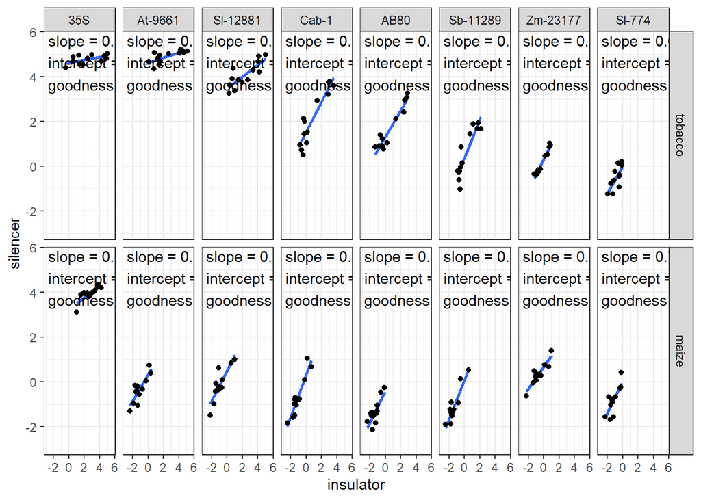

```r
enh_order <- data_ExI_enhancers |>
  filter(sys == 'tobacco') |>
  distinct(enhancer, rank) |>
  arrange(desc(rank)) |>
  pull(enhancer)

data_ExI_IvS <- data_ExI_mean |>
  select(sys, construct, enhancer, insulator, start, stop, enrichment) |>
  mutate(
    construct = if_else(insulator == 'noIns', 'insulator/silencer', construct),
    enhancer = ordered(enhancer, levels = enh_order)
  ) |>
  separate_longer_delim(
    construct,
    delim = '/'
  ) |>
  unite(
    'id',
    insulator,
    start,
    stop,
    na.rm = TRUE
  ) |>
  filter(construct != 'noEnh') |>
  pivot_wider(
    names_from = construct,
    values_from = enrichment
  ) |>
  drop_na(insulator, silencer)

 data_ExI_IvS |>
   pggfplot(
    filename = 'ExI_IvS',
    x = insulator,
    y = silencer,
    facet_col = enhancer,
    facet_row = sys,
    scales = 'square'
  ) |>
  pggf_trendline() |>
  pggf_stats(!! pggf_stat_fns$trendline) |>
  pggf_scatter()
```

When we can compare the slope of these regression lines to the strength of the enhancer, we observe a decent correlation.

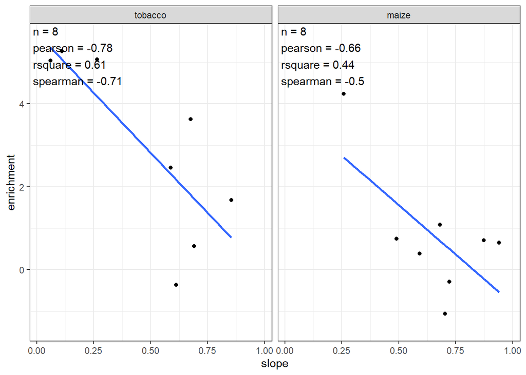

```r
data_ExI_IvS |>
  group_by(sys, enhancer) |>
  summarise(
    slope = lm(silencer ~ insulator)$coefficients[2],
    .groups = 'drop'
  ) |>
  inner_join(
    data_ExI_enhancers |>
      group_by(sys, enhancer) |>
      summarise(
        enrichment = median(enrichment),
        .groups = 'drop'
      ),
    by = c('sys', 'enhancer')
  ) |>
  pggfplot(
    filename = 'ExI_cor_slope',
    x = slope,
    y = enrichment,
    facet_col = sys
  ) |>
  pggf_trendline() |>
  pggf_stats(!! pggf_stat_fns$correlation) |>
  pggf_scatter()
```

Export data to a Supplementary Data file:

```r
DS_id <- 5

data_ExI_export <- data_ExI_mean |>
  select(sys, construct, enhancer, insulator, start, stop, enrichment) |>
  pivot_wider(
    names_from = sys,
    values_from = enrichment
  ) |>
  arrange(construct, enhancer, insulator, start, stop) |>
  mutate(
    sequence = str_sub(FLins_seqs[as.character(insulator)], start, stop),
    sequence = replace_na(sequence, ''),
    insulator = str_replace(insulator, 'beta', 'β'),
    insulator = str_replace(insulator, 'lambda', 'λ')
  )

wb <- createWorkbook()

modifyBaseFont(wb, fontSize = 10, fontName = 'Arial')

addWorksheet(wb, sheetName = 'enhancer-insulator combinations')

writeData(
  wb,
  sheet = 1,
  paste0('Supplementary Dataset S', DS_id,'. Enrichment of insulator and silencer constructs with eight different enhancers.'),
  startCol = 1,
  startRow = 1
)

makeNameBold(wb, DS_id)
mergeCells(wb, sheet = 1, rows = 1, cols = seq_len(ncol(data_ExI_export)))

writeData(
  wb,
  sheet = 1,
  paste(
    "Selected insulators and insulator fragments were cloned in between (insulator construct) or upstream of (silencer construct) an enhancer",
    "and a 35S minimal promoter driving the expression of a barcoded GFP reporter gene. Eight different enhancers were used to build these",
    "constructs. All constructs were pooled andsubjected to Plant STARR-seq in N. benthamiana leaves (tobacco) or maize protoplasts (maize).",
    "Reporter mRNA enrichment was normalized to a control construct without an enhancer or insulator (noEnh; log2 set to 0)."
  ),
  startCol = 1,
  startRow = 2
)

addStyle(wb, sheet = 1, style = xlsx_wrap, rows = 2, cols = 1)
mergeCells(wb, sheet = 1, rows = 2, cols = seq_len(ncol(data_ExI_export)))
setRowHeights(wb, sheet = 1, rows = 2, heights = 12.75 * 5)

xlsx_header <- names(data_ExI_export)
enrichment_ids <- which(xlsx_header %in% c('tobacco', 'maize'))
xlsx_header[enrichment_ids] <- 'log2(enrichment)'

writeData(
  wb,
  sheet = 1,
  matrix(xlsx_header, nrow = 1),
  startCol = 1,
  startRow = 4,
  colNames = FALSE
)

addStyle(wb, sheet = 1, style = xlsx_boldwrap, cols = seq_along(xlsx_header), rows = 4)

writeData(
  wb,
  sheet = 1,
  data_ExI_export,
  startCol = 1,
  startRow = 5,
  headerStyle = xlsx_bold,
  keepNA = TRUE
)

mergeCells(wb, sheet = 1, rows = 4, cols = enrichment_ids)
addStyle(wb, sheet = 1, style = xlsx_center, rows = 4, cols = enrichment_ids, stack = TRUE)

for (i in seq_along(xlsx_header)[-enrichment_ids]) {
  mergeCells(wb, sheet = 1, rows = 4:5, cols = i)
}

addStyle(wb, sheet = 1, style = xlsx_2digit, cols = enrichment_ids, rows = 6:(nrow(data_ExI_export) + 6), gridExpand = TRUE)
addStyle(wb, sheet = 1, style = xlsx_seq_font, cols = which(xlsx_header == 'sequence'), rows = 6:(nrow(data_ExI_export) + 6))

freezePane(wb, sheet = 1, firstActiveRow = 6)

saveWorkbook(wb, paste0(supp_data_dir, 'SupplementaryDataset', DS_id, '.xlsx'), overwrite = TRUE)
```

## Silencer constructs in stable lines

We also tested some of the full-length insulators in a silencer construct in stable *Arabidopsis* lines.

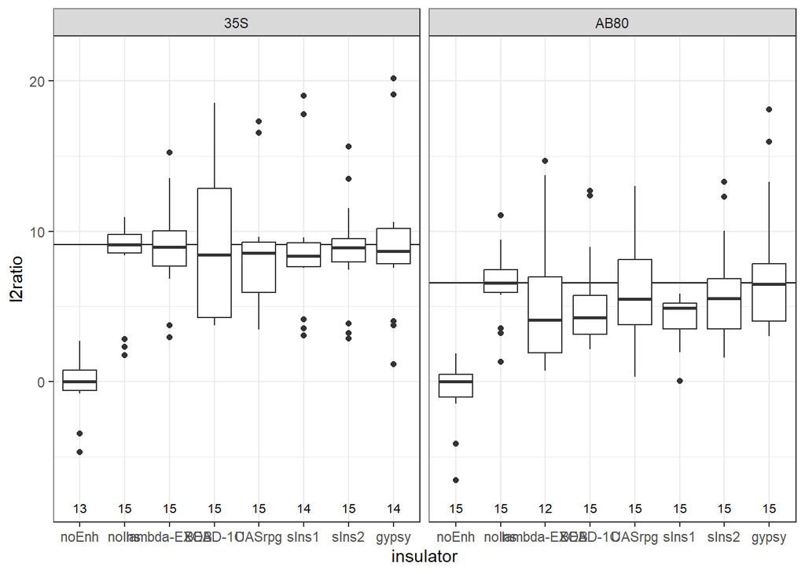

```r
data_DL |>
  filter(set %in% c('FLsil', 'silAB') | (insulator %in% c('noEnh', 'noIns') & set == 'insAB')) |>
  pggfplot(
    filename = 'DL_sil',
    x = insulator,
    y = l2ratio,
    facet_col = enhancer
  ) |>
  pggf_hline(median(y[xticklabels == 'noIns'])) |>
  pggf_boxplot()
```

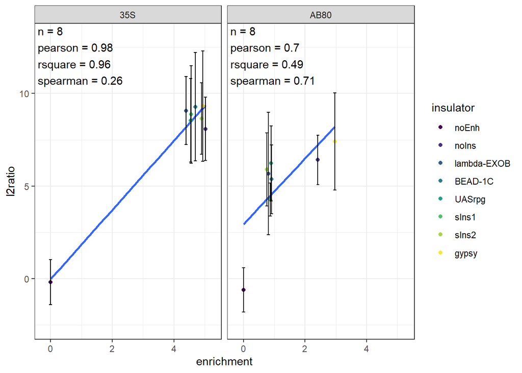

```r
data_DL_sil_summary <- data_DL |>
  filter(set %in% c('FLsil', 'silAB') | (insulator %in% c('noEnh', 'noIns') & set == 'insAB')) |>
  group_by(enhancer, insulator) |>
  summarise(
    CI = 0.5 * diff(t.test(l2ratio)$conf.int),
    l2ratio = mean(l2ratio),
    .groups = 'drop'
  )

data_ExI_mean |>
  mutate(
    enhancer = if_else(insulator == 'noEnh', '35S/AB80', enhancer)
  ) |>
  separate_longer_delim(
    enhancer,
    delim = '/'
  ) |>
  filter(sys == 'tobacco' & enhancer %in% c('35S', 'AB80') & (insulator %in% c('noEnh', 'noIns') | (type == 'FL' & construct == 'silencer'))) |>
  group_by(enhancer, insulator) |>
  summarise(
    enrichment = mean(enrichment),
    .groups = 'drop'
  ) |>
  inner_join(
    data_DL_sil_summary,
    by = c('enhancer', 'insulator')
  ) |>
  pggfplot(
    filename = 'DL_cor_sil',
    x = enrichment,
    y = l2ratio,
    facet_col = enhancer
  ) |>
  pggf_trendline() |>
  pggf_scatter(
    color = insulator,
    y_error = CI
  ) |>
  pggf_stats(!! pggf_stat_fns$correlation)
```

Similar to our findings in tobacco, the slope of the `silencer ~ insulator` regression line is higher for the *AB80* enhancer as compared to the slope for the 35S enhancer.

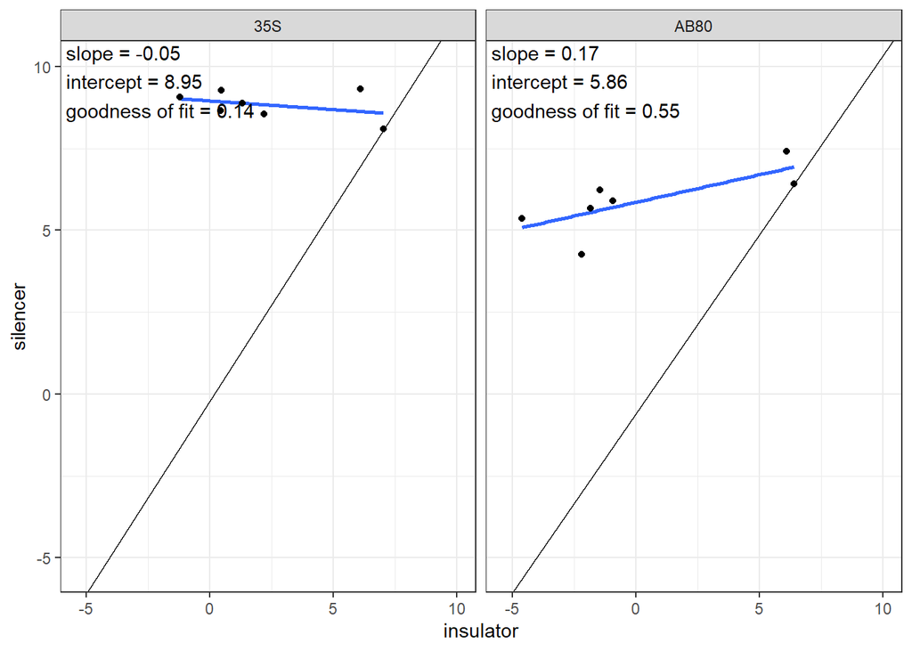

```r
data_DL |>
  filter(grepl('ins|sil', set)) |>
  mutate(
    construct = if_else(grepl('ins', set), 'insulator', 'silencer'),
    construct = if_else(enhancer == 'AB80' & grepl('no', insulator, fixed = TRUE), 'insulator/silencer', construct)
  ) |>
  group_by(construct, 'id' = insulator, enhancer) |>
  summarise(
    l2ratio = mean(l2ratio),
    .groups = 'drop'
  ) |>
  separate_longer_delim(
    construct,
    delim = '/'
  ) |>
  pivot_wider(
    names_from = construct,
    values_from = l2ratio
  ) |>
  group_by(enhancer) |>
  mutate(
    slope = (silencer[id == 'noIns'] - silencer[id == 'noEnh']) / insulator[id == 'noIns'],
    intercept = silencer[id == 'noEnh']
  ) |>
  ungroup() |>
  filter(id != 'noEnh') |>
  pggfplot(
    filename = 'DL_IvS',
    x = insulator,
    y = silencer,
    facet_col = enhancer,
    scales = 'square'
  ) |>
  pggf_trendline() |>
  pggf_stats(!! pggf_stat_fns$trendline) |>
  pggf_scatter() |>
  pggf_abline(slope = unique(slope), intercept = unique(intercept))
```